# Machine Learning

## Indah Agustien Siradjuddin

## Logistic Regression

Semester Gasal 2019-2020

## Regression Vs. Classification

Regression : input - real value, output - real value  
Classification : input - real value, output - kelas

## Binary Classifier

- memetakan input ke output, dimana hanya terdapat dua jenis nilai pada output, yaitu, positif dan negatif
- Target Data : 1 dan 0, atau 1 dan -1

Contoh :

- Email : *Spam* atau *ham*
- Kanker : *benign* atau *malignant*
- Transaksi CC : *Fraud* or *regular transaction*

Output :

$y \in {0,1}$, dimana:

- 0 adalah kelas negatif
- 1 adalah kelas positif

**note :** Kelas 0 dan 1 tergantung bagaimana kita menentukan apa yang disebut positif dan negatif

## Linear Regression untuk Permasalahan Klasifikasi

### Identifikasi Email Spam

berdasarkan jumlah kata 'iklan'  
Nilai output

- Spam : 1
- Ham : 0

[figure not shown]

Berdasarkan data training, berikut adalah model linear regression :

[figure not shown]

**Linear Regression for classification --> threshold** Threshold digunakan untuk memisahkan kelas:  
$if output<threshold$ then $output=0$, else $output=1$

[figure not shown]

Berdasarkan threshold tersebut, dapat ditentukan email adalah spam atau ham

Jika, terdapat data baru, model akan diupdate

[figure not shown]

berdasarkan threshold tersebut, data-data mana yang termasuk spam dan ham ?

**Oleh karena itu Linear Regression Model tidak dapat digunakan untuk Klasifikasi**

## Definisi

- Prediksi probabilitas suatu data termasuk ke dalam kelas tertentu
- *binary classifier*
- *Supervised classifier*

## Fungsi *Logistic*

output of logistic function falls to $ 0\leq y \leq 1$ Fungsi logistik : \begin{eqnarray} y=f(x)=\frac{1}{1+e^{-x}} \end{eqnarray}

[figure not shown]

Linear Regression : \begin{eqnarray} f(x;w)=w_0+w_1x_1+w_2x_2+...+w_dx_d \end{eqnarray} Logistic Regression : \begin{eqnarray} f(x;w)=\frac{1}{1+e^{-(w_0+w_1x_1+w_2x_2+...+w_dx_d)}} \end{eqnarray}

*Update weight* dengan *Gradient descent* : \begin{eqnarray} w_j=w_j+\eta(y^i-f(x^i))f(x^i)(1-f(x^i))x_j^i \end{eqnarray}

```python
import numpy as np
x=np.array([[3,3],[1,2],[3,4],[1,2],[3,3],[8,3],[5,2],[7,2],[9,0],[8,4]])
target=np.array([[0],[0],[0],[0],[0],[1],[1],[1],[1],[1]])
test=np.array([[1,2]])
```

## Kode Program Logistic Regression

```python
import simpleLinear
```

```python
simpleLinear.logRegression(10,0.3,x,target)
```

```
w= [[0.]
 [0.]
 [0.]]
output= [0.5]  error - 0 = [-0.5]
w= [[-0.0375]
 [-0.1125]
 [-0.1125]]
output= [0.4073334]  error - 1 = [-0.4073334]
w= [[-0.06700066]
 [-0.14200066]
 [-0.17150132]]
output= [0.23523062]  error - 2 = [-0.23523062]
w= [[-0.07969586]
 [-0.18008625]
 [-0.22228211]]
output= [0.3308493]  error - 3 = [-0.3308493]
w= [[-0.10166968]
 [-0.20206008]
 [-0.26622976]]
output= [0.18145225]  error - 4 = [-0.18145225]
w= [[-0.10975487]
 [-0.22631563]
 [-0.29048531]]
output= [0.05777239]  error - 5 = [0.94222761]
w= [[-0.09436789]
 [-0.10321983]
 [-0.24432439]]
output= [0.2499056]  error - 6 = [0.7500944]
w= [[-0.05218571]
 [ 0.1076911 ]
 [-0.15996002]]
output= [0.59429076]  error - 7 = [0.40570924]
w= [[-0.02283963]
 [ 0.31311363]
 [-0.10126787]]
output= [0.94241497]  error - 8 = [0.05758503]
w= [[-0.02190211]
 [ 0.32155135]
 [-0.10126787]]
output= [0.89524163]  error - 9 = [0.10475837]
```

[output cut: 345 more lines]

```
 [ 0.78246732]
 [-1.15201666]]
output= [0.77054013]  error - 6 = [0.22945987]
w= [[-0.38476862]
 [ 0.84332285]
 [-1.12767445]]
output= [0.96314251]  error - 7 = [0.03685749]
w= [[-0.3843761 ]
 [ 0.8460705 ]
 [-1.12688941]]
output= [0.99927619]  error - 8 = [0.00072381]
w= [[-0.38437594]
 [ 0.84607191]
 [-1.12688941]]
output= [0.86722491]  error - 9 = [0.13277509]
```

## Logistic Regression dengan Scikit

**Training/Learning**

- load dataset (fitur dan target)
- Buat Model
- Training/Learning

**Testing**

- Load Model
- test model dengan data input baru / *Generalize*

```python
from sklearn.linear_model.logistic import LogisticRegression
import numpy as np
```

```python
classifier = LogisticRegression()
classifier.fit(x,target)
print(classifier.intercept_,classifier.coef_)
pred=classifier.predict(test)
print('prediction = ',pred)
```

```
[-0.40885175] [[ 0.83023895 -1.10760329]]
prediction =  [0]
```

[output not shown]

## Akurasi

Perhitungan akurasi yang paling sederhana untuk klasifikasi adalah menghitung jumlah prediksi yang benar dibandingkan dengan jumlah seluruh data test :

$akurasi=\frac{True}{JumlahData}$

```python
from sklearn.metrics import accuracy_score
import numpy as np
```

```python
target=np.array([0,0,0,0,0,1,1,1,1,1])
pred=np.array([0,1,0,0,0,0,0,1,1,1])
acc=accuracy_score(target,pred)
print(acc)
```

```
0.7
```

## *Confusion Matrix*

Hitung True Positive, True Negative, False Positive, dan False Negative

**Positive - Negative** : class  
**True - False** : apakah hasil prediksi sesuai dengan target?  
**Identifikasi Email : Identifikasi spam**  
Positive class : Spam Email Negative class : ham email

**True Positive** : jika data diprediksikan sebagai kelas positif, dan target adalah positif, yaitu, output = spam, target = spam

**True Negative** : jika data diprediksikan sebagai kelas negatif, dan target adalah negatif, yaitu, output = ham, target = ham

**False Positive** : jika data diprediksikan sebagai kelas positif, dan target adalah negatif, yaitu, output = spam, dan target=ham

**False Negative** : jika data diprediksikan sebagai kelas negatif, dan target adalah kelas positif, yaitu, output = ham, target = spam

```python
from sklearn.metrics import confusion_matrix
import matplotlib.pyplot as plt
import numpy as np
```

```
[[4 1]
 [2 3]]
```

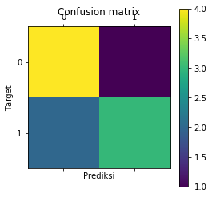

```python
target=np.array([0,0,0,0,0,1,1,1,1,1])
pred=np.array([0,1,0,0,0,0,0,1,1,1])
confusionMatrix = confusion_matrix(target, pred)
print(confusionMatrix)
plt.matshow(confusionMatrix)
plt.title('Confusion matrix')
plt.colorbar()
plt.ylabel('Target')
plt.xlabel('Prediksi')
plt.show()
```

```python
TP=3
TN=4
FP=1 # prediksi positive, target negative
FN=2 # prediksi negative, target positive
```

## Precision - Recall

$precision=\frac{TP}{TP+FP}$

$recall=\frac{TP}{TP+FN}$

```python
from sklearn.metrics import precision_score
from sklearn.metrics import recall_score
print(precision_score(target, pred))
print(recall_score(target, pred))
```

```
0.75
0.6
```